# Probability Distributions of $Y$

and Simulated Sampling Distributions of $\bar{Y}$

2024-10-01

**The take-home point here:** as $N$ becomes large, the Central Limit Theorem tells us that the distribution of the sampling distribution of $\bar{Y}$ converges to the Normal with an ever-smaller variance. This is true, perhaps unsurprisingly, when the distribution of $Y$ is itself nearly Normal (example 1). But it is also true for any and all possible distributions of $Y$, including those that are best described as “bimodal” (example 2) or skewed (example 3). Thus when $n$ is large, no assumptions about the distribution of $Y$ are necessary to fully describe the sampling distribution of $\bar{Y}$ . Under this circumstance, $\bar{Y}$ is distributed Normal with mean $\mu_Y$ and variance $\frac{\sigma_Y^2}{n}$.

## Example 1: The Random Variable $Y$ takes on a nearly **Normal Distribution**

```r
set.seed(123)
require(tidyverse)
Y <- rnorm(n = 10000,mean = 5,sd = sqrt(3))
```

### The probability distribution of $Y$ (table)

```r
data.frame(Y = round(Y)) %>%
  count(Y) %>%
  mutate(`p(Y=y)` = n / sum(n))
```

```
##     Y    n p(Y=y)
## 1  -2    1 0.0001
## 2  -1    6 0.0006
## 3   0   39 0.0039
## 4   1  169 0.0169
## 5   2  532 0.0532
## 6   3 1194 0.1194
## 7   4 1905 0.1905
## 8   5 2307 0.2307
## 9   6 1915 0.1915
## 10  7 1202 0.1202
## 11  8  521 0.0521
## 12  9  160 0.0160
## 13 10   37 0.0037
## 14 11   11 0.0011
## 15 12    1 0.0001
```

### The probability distribution of $Y$ (histogram)

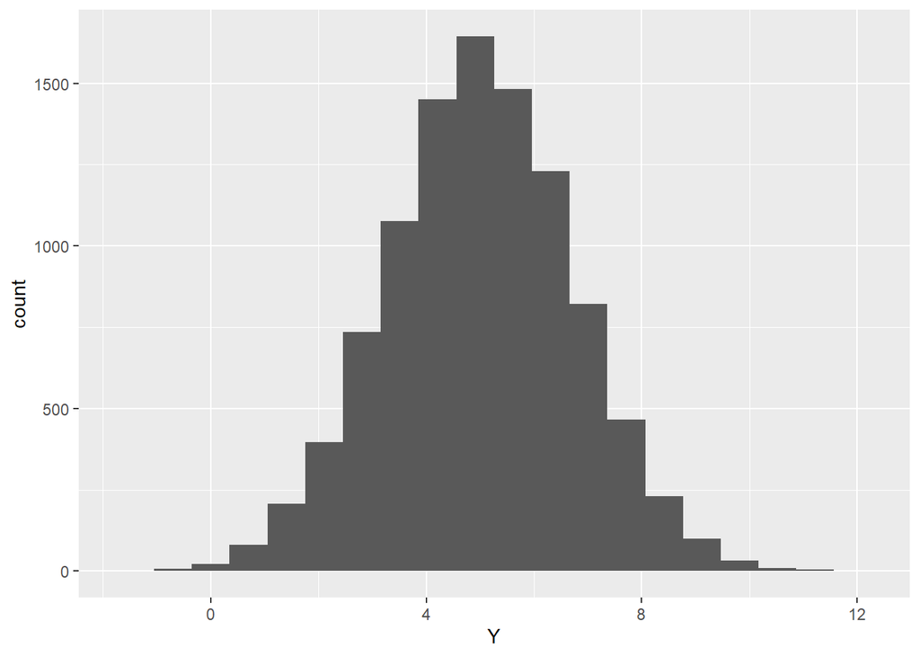

```r
data.frame(Y = Y) %>%
  ggplot(aes(x = Y)) +
  geom_histogram(bins = 20)
```

### The sampling distribution of $\bar{Y}$ at different sizes

```r
toplot <- NULL
for(s in c(5,25,1000)) {
  cat(s,'\n')
  for(i in 1:5000) {
    toplot <- toplot %>%
      bind_rows(data.frame(Y = Y) %>%
      sample_n(size = s) %>%
      summarise(ybar = mean(Y)) %>%
        mutate(size = s))
  }
}
```

```
## 5
## 25
## 1000
```

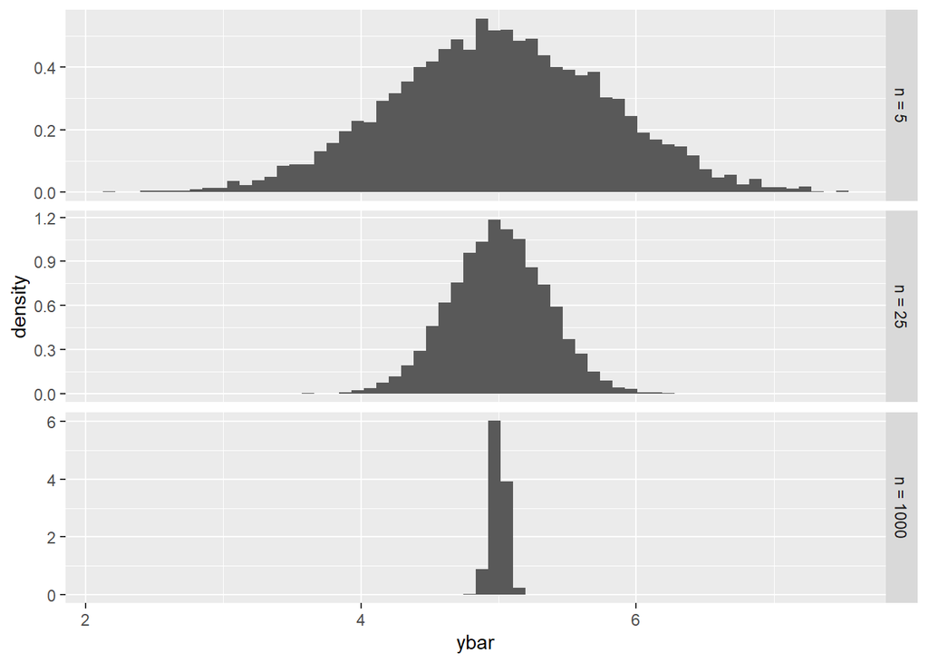

```r
toplot %>%
  mutate(size = factor(paste0('n = ',size),levels = c('n = 5','n = 25','n = 1000'))) %>%
  ggplot(aes(x = ybar)) +
  geom_histogram(bins = 60,aes(y = ..density..)) +
  facet_grid(size~.,scales = 'free_y')
```

Note that we can calculate mean and standard deviation of these results as follows:

```r
# Mean: E(Y-bar) = \mu = 5
toplot %>%
  group_by(size) %>%
  summarise(mu = mean(ybar))
```

```
## # A tibble: 3 × 2
##    size    mu
##   <dbl> <dbl>
## 1     5  5.00
## 2    25  5.00
## 3  1000  5.00
```

```r
# Std Dev: \sigma_Y-bar = sqrt(var(y-bar)) = sqrt(\sigma^2 / n) approx \sqrt(3) / \sqrt(n)
toplot %>%
  group_by(size) %>%
  summarise(sigma = sqrt(3)/sqrt(size),
            sigma_p = sd(ybar)) %>%
  distinct()
```

```
## # A tibble: 3 × 3
## # Groups:   size [3]
##    size  sigma sigma_p
##   <dbl>  <dbl>   <dbl>
## 1     5 0.775   0.777
## 2    25 0.346   0.349
## 3  1000 0.0548  0.0523
```

## Example 2: The Random Variable $Y$ takes on a nearly **Bimodal Distribution**

```r
set.seed(123)
Y <- c(rnorm(n = 5000,mean = 2,sd = sqrt(2)),rnorm(n = 5000,mean = 7,sd = sqrt(2)))
```

### The probability distribution of $Y$ (table)

```r
data.frame(Y = round(Y)) %>%
  count(Y) %>%
  mutate(`p(Y=y)` = n / sum(n))
```

```
##     Y    n p(Y=y)
## 1  -2   30 0.0030
## 2  -1  173 0.0173
## 3   0  513 0.0513
## 4   1 1066 0.1066
## 5   2 1414 0.1414
## 6   3 1123 0.1123
## 7   4  686 0.0686
## 8   5  701 0.0701
## 9   6 1079 0.1079
## 10  7 1426 0.1426
## 11  8 1061 0.1061
## 12  9  526 0.0526
## 13 10  175 0.0175
## 14 11   23 0.0023
## 15 12    4 0.0004
```

### The probability distribution of $Y$ (histogram)

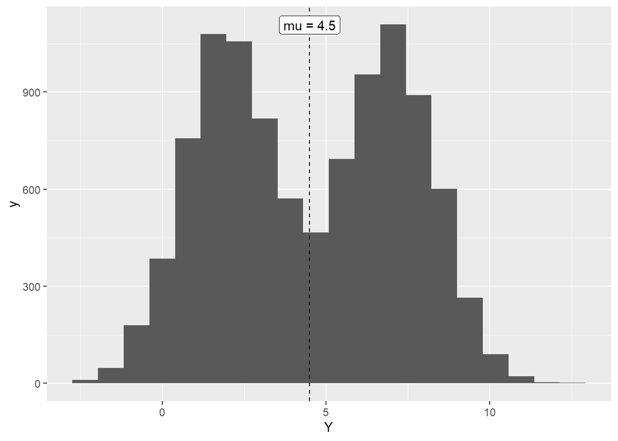

```r
data.frame(Y = Y) %>%
  ggplot(aes(x = Y)) +
  geom_histogram(bins = 20) +
  geom_vline(xintercept = mean(Y),linetype = 'dashed') +
  annotate(geom = 'label',x = mean(Y),y = Inf,label = paste0('mu = ',round(mean(Y),2)),vjust = 1.5)
```

### The sampling distribution of $\bar{Y}$ at different sizes

```r
toplot <- NULL
for(s in c(5,25,1000)) {
  cat(s,'\n')
  for(i in 1:5000) {
    toplot <- toplot %>%
      bind_rows(data.frame(Y = Y) %>%
      sample_n(size = s) %>%
      summarise(ybar = mean(Y)) %>%
        mutate(size = s))
  }
}
```

```
## 5
## 25
## 1000
```

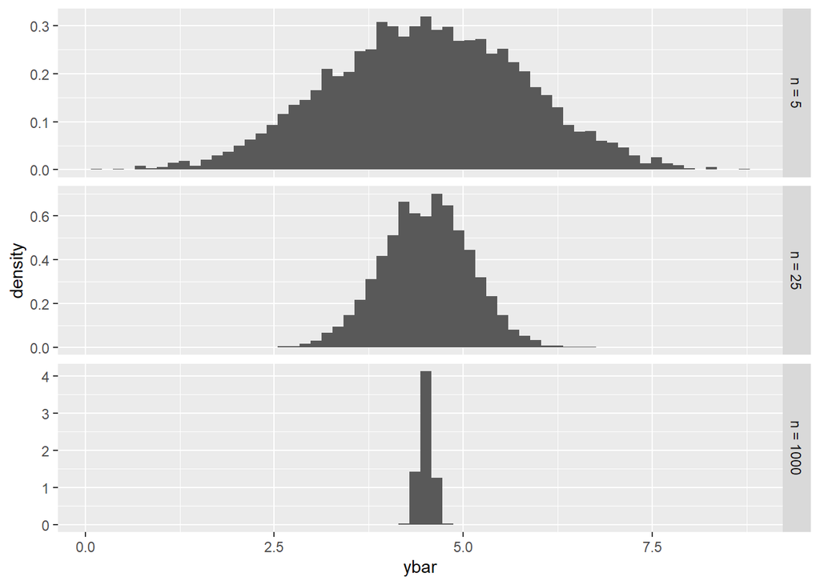

```r
toplot %>%
  mutate(size = factor(paste0('n = ',size),levels = c('n = 5','n = 25','n = 1000'))) %>%
  ggplot(aes(x = ybar)) +
  geom_histogram(bins = 60,aes(y = ..density..)) +
  facet_grid(size~.,scales = 'free_y')
```

```r
# Mean: E(Y-bar) = \mu = 4.5
toplot %>%
  group_by(size) %>%
  summarise(mu = mean(ybar))
```

```
## # A tibble: 3 × 2
##    size    mu
##   <dbl> <dbl>
## 1     5  4.50
## 2    25  4.50
## 3  1000  4.50
```

```r
# Std Dev: \sigma_Y-bar
toplot %>%
  group_by(size) %>%
  summarise(sigma = sd(ybar)) %>%
  distinct()
```

```
## # A tibble: 3 × 2
##    size  sigma
##   <dbl>  <dbl>
## 1     5 1.27
## 2    25 0.575
## 3  1000 0.0856
```

## Example 3: The Random Variable $Y$ takes on a **Skewed Distribution**

```r
set.seed(123)
Y <- rgamma(n = 10000,shape = 1,rate = 1)
```

### The probability distribution of $Y$ (table)

```r
data.frame(Y = round(Y)) %>%
  count(Y) %>%
  mutate(`p(Y=y)` = n / sum(n))
```

```
##     Y    n p(Y=y)
## 1   0 4000 0.4000
## 2   1 3860 0.3860
## 3   2 1381 0.1381
## 4   3  457 0.0457
## 5   4  191 0.0191
## 6   5   68 0.0068
## 7   6   27 0.0027
## 8   7    9 0.0009
## 9   8    4 0.0004
## 10  9    2 0.0002
## 11 10    1 0.0001
```

### The probability distribution of $Y$ (histogram)

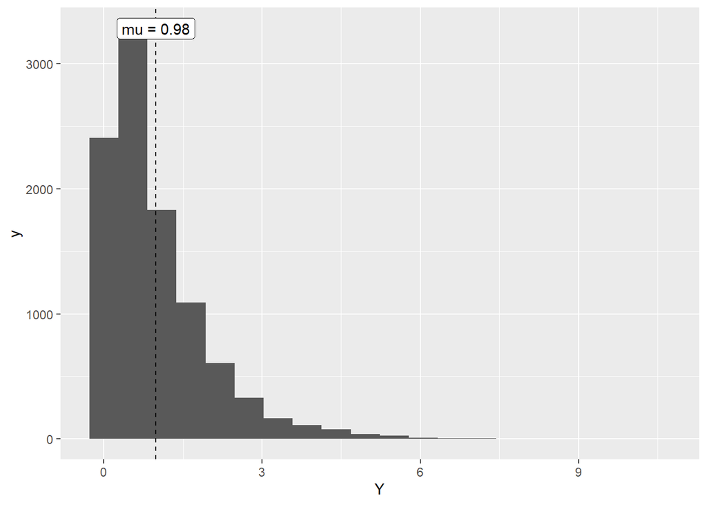

```r
data.frame(Y = Y) %>%
  ggplot(aes(x = Y)) +
  geom_histogram(bins = 20) +
  geom_vline(xintercept = mean(Y),linetype = 'dashed') +
  annotate(geom = 'label',x = mean(Y),y = Inf,label = paste0('mu = ',round(mean(Y),2)),vjust = 1.5)
```

### The sampling distribution of $\bar{Y}$ at different sizes

```r
toplot <- NULL
for(s in c(5,25,1000)) {
  cat(s,'\n')
  for(i in 1:5000) {
    toplot <- toplot %>%
      bind_rows(data.frame(Y = Y) %>%
      sample_n(size = s) %>%
      summarise(ybar = mean(Y)) %>%
        mutate(size = s))
  }
}
```

```
## 5
## 25
## 1000
```

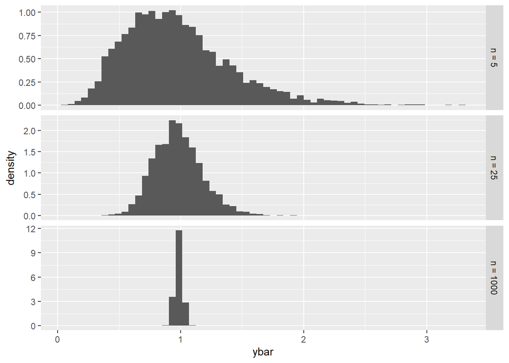

```r
toplot %>%
  mutate(size = factor(paste0('n = ',size),levels = c('n = 5','n = 25','n = 1000'))) %>%
  ggplot(aes(x = ybar)) +
  geom_histogram(bins = 60,aes(y = ..density..)) +
  facet_grid(size~.,scales = 'free_y')
```

```r
# Mean: E(Y-bar) = 1
toplot %>%
  group_by(size) %>%
  summarise(mu = mean(ybar))
```

```
## # A tibble: 3 × 2
##    size    mu
##   <dbl> <dbl>
## 1     5 0.974
## 2    25 0.980
## 3  1000 0.984
```

```r
# Std Dev: \sigma_Y-bar = 1
toplot %>%
  group_by(size) %>%
  summarise(sigma = sd(ybar)) %>%
  distinct()
```

```
## # A tibble: 3 × 2
##    size  sigma
##   <dbl>  <dbl>
## 1     5 0.433
## 2    25 0.194
## 3  1000 0.0296
```

[^1]: Note that I chose 5,000 as a large number that could nevertheless be done in a short amount of time on a standard computer. But this number doesn’t matter. I could have picked 10,000 or 10 million such iterations: at higher numbers of iterations, the histograms would be smoother but would otherwise remain similar.